# Risk Factor Analysis

## Outcome Variable

**Outcome Variable:** haz

## Predictor Variables

**Intervention Variable:** exclfeed3

**Adjustment Set:**

- arm
- sex
- brthmon
- W_mage
- meducyrs
- feducyrs
- hhwealth_quart
- hfoodsec
- W_mhtcm
- W_mwtkg
- W_mbmi
- vagbrth
- W_gagebrth
- W_birthwt
- W_birthlen
- W_nrooms
- W_nchldlt5
- month
- W_parity
- impfloor
- impsan
- safeh20
- delta_W_mage
- delta_meducyrs
- delta_feducyrs
- delta_hhwealth_quart
- delta_hfoodsec
- delta_W_mhtcm
- delta_W_mwtkg
- delta_W_mbmi
- delta_vagbrth
- delta_W_gagebrth
- delta_W_birthwt
- delta_W_birthlen
- delta_W_nrooms
- delta_W_nchldlt5
- delta_month
- delta_W_parity
- delta_impfloor
- delta_impsan
- delta_safeh20

## Stratifying Variables

The analysis was stratified on these variable(s):

- agecat
- studyid
- country

## Data Summary

| agecat | studyid | country | exclfeed3 | n_cell | n | outcome_variable |
| --- | --- | --- | --- | --- | --- | --- |
| Birth | CMC-V-BCS-2002 | INDIA | 1 | 4 | 4 | haz |
| Birth | CMC-V-BCS-2002 | INDIA | 0 | 0 | 4 | haz |
| Birth | EE | PAKISTAN | 1 | 35 | 35 | haz |
| Birth | EE | PAKISTAN | 0 | 0 | 35 | haz |
| Birth | GMS-Nepal | NEPAL | 1 | 380 | 458 | haz |
| Birth | GMS-Nepal | NEPAL | 0 | 78 | 458 | haz |
| Birth | IRC | INDIA | 1 | 0 | 10 | haz |
| Birth | IRC | INDIA | 0 | 10 | 10 | haz |
| Birth | JiVitA-3 | BANGLADESH | 1 | 12014 | 13276 | haz |
| Birth | JiVitA-3 | BANGLADESH | 0 | 1262 | 13276 | haz |
| Birth | JiVitA-4 | BANGLADESH | 1 | 105 | 116 | haz |
| Birth | JiVitA-4 | BANGLADESH | 0 | 11 | 116 | haz |
| Birth | Keneba | GAMBIA | 1 | 1198 | 1356 | haz |
| Birth | Keneba | GAMBIA | 0 | 158 | 1356 | haz |
| Birth | MAL-ED | BANGLADESH | 1 | 138 | 215 | haz |
| Birth | MAL-ED | BANGLADESH | 0 | 77 | 215 | haz |
| Birth | MAL-ED | BRAZIL | 1 | 12 | 57 | haz |
| Birth | MAL-ED | BRAZIL | 0 | 45 | 57 | haz |
| Birth | MAL-ED | INDIA | 1 | 24 | 41 | haz |
| Birth | MAL-ED | INDIA | 0 | 17 | 41 | haz |
| Birth | MAL-ED | NEPAL | 1 | 8 | 26 | haz |
| Birth | MAL-ED | NEPAL | 0 | 18 | 26 | haz |
| Birth | MAL-ED | PERU | 1 | 49 | 223 | haz |
| Birth | MAL-ED | PERU | 0 | 174 | 223 | haz |
| Birth | MAL-ED | SOUTH AFRICA | 1 | 12 | 100 | haz |
| Birth | MAL-ED | SOUTH AFRICA | 0 | 88 | 100 | haz |
| Birth | MAL-ED | TANZANIA, UNITED REPUBLIC OF | 1 | 17 | 102 | haz |
| Birth | MAL-ED | TANZANIA, UNITED REPUBLIC OF | 0 | 85 | 102 | haz |
| Birth | PROVIDE | BANGLADESH | 1 | 387 | 539 | haz |
| Birth | PROVIDE | BANGLADESH | 0 | 152 | 539 | haz |

[output cut: 64 more lines]

The following strata were considered:

- agecat: 24 months, studyid: CMC-V-BCS-2002, country: INDIA
- agecat: 24 months, studyid: EE, country: PAKISTAN
- agecat: 24 months, studyid: GMS-Nepal, country: NEPAL
- agecat: 24 months, studyid: IRC, country: INDIA
- agecat: 24 months, studyid: JiVitA-3, country: BANGLADESH
- agecat: 24 months, studyid: JiVitA-4, country: BANGLADESH
- agecat: 24 months, studyid: Keneba, country: GAMBIA
- agecat: 24 months, studyid: MAL-ED, country: BANGLADESH
- agecat: 24 months, studyid: MAL-ED, country: BRAZIL
- agecat: 24 months, studyid: MAL-ED, country: INDIA
- agecat: 24 months, studyid: MAL-ED, country: NEPAL
- agecat: 24 months, studyid: MAL-ED, country: PERU
- agecat: 24 months, studyid: MAL-ED, country: SOUTH AFRICA
- agecat: 24 months, studyid: MAL-ED, country: TANZANIA, UNITED REPUBLIC OF
- agecat: 24 months, studyid: PROVIDE, country: BANGLADESH
- agecat: 6 months, studyid: CMC-V-BCS-2002, country: INDIA
- agecat: 6 months, studyid: EE, country: PAKISTAN
- agecat: 6 months, studyid: GMS-Nepal, country: NEPAL
- agecat: 6 months, studyid: IRC, country: INDIA
- agecat: 6 months, studyid: JiVitA-3, country: BANGLADESH
- agecat: 6 months, studyid: JiVitA-4, country: BANGLADESH
- agecat: 6 months, studyid: Keneba, country: GAMBIA
- agecat: 6 months, studyid: MAL-ED, country: BANGLADESH
- agecat: 6 months, studyid: MAL-ED, country: BRAZIL
- agecat: 6 months, studyid: MAL-ED, country: INDIA
- agecat: 6 months, studyid: MAL-ED, country: NEPAL
- agecat: 6 months, studyid: MAL-ED, country: PERU
- agecat: 6 months, studyid: MAL-ED, country: SOUTH AFRICA
- agecat: 6 months, studyid: MAL-ED, country: TANZANIA, UNITED REPUBLIC OF
- agecat: 6 months, studyid: PROVIDE, country: BANGLADESH
- agecat: 6 months, studyid: SAS-CompFeed, country: INDIA
- agecat: Birth, studyid: CMC-V-BCS-2002, country: INDIA
- agecat: Birth, studyid: EE, country: PAKISTAN
- agecat: Birth, studyid: GMS-Nepal, country: NEPAL
- agecat: Birth, studyid: IRC, country: INDIA
- agecat: Birth, studyid: JiVitA-3, country: BANGLADESH
- agecat: Birth, studyid: JiVitA-4, country: BANGLADESH
- agecat: Birth, studyid: Keneba, country: GAMBIA
- agecat: Birth, studyid: MAL-ED, country: BANGLADESH
- agecat: Birth, studyid: MAL-ED, country: BRAZIL
- agecat: Birth, studyid: MAL-ED, country: INDIA
- agecat: Birth, studyid: MAL-ED, country: NEPAL
- agecat: Birth, studyid: MAL-ED, country: PERU
- agecat: Birth, studyid: MAL-ED, country: SOUTH AFRICA
- agecat: Birth, studyid: MAL-ED, country: TANZANIA, UNITED REPUBLIC OF
- agecat: Birth, studyid: PROVIDE, country: BANGLADESH
- agecat: Birth, studyid: SAS-CompFeed, country: INDIA

### Dropped Strata

- agecat: Birth, studyid: CMC-V-BCS-2002, country: INDIA
- agecat: Birth, studyid: EE, country: PAKISTAN
- agecat: Birth, studyid: IRC, country: INDIA
- agecat: 6 months, studyid: CMC-V-BCS-2002, country: INDIA
- agecat: 6 months, studyid: EE, country: PAKISTAN
- agecat: 6 months, studyid: IRC, country: INDIA
- agecat: 24 months, studyid: CMC-V-BCS-2002, country: INDIA
- agecat: 24 months, studyid: EE, country: PAKISTAN
- agecat: 24 months, studyid: IRC, country: INDIA

## Methods Detail

We’re interested in the causal parameters $E[Y_a]$ for all values of $a \in \mathcal{A}$. These parameters represent the mean outcome if, possibly contrary to fact, we intervened to set all units to have $A=a$. Under the randomization and positivity assumptions, these are identified by the statistical parameters $\psi_a=E_W[E_{Y|A,W}(Y|A=a,W)]$. In addition, we’re interested in the mean of $Y$, $E[Y]$ under no intervention (the observed mean). We will estimate these parameters by using SuperLearner to fit the relevant likelihood factors – $E_{Y|A,W}(Y|A=a,W)$ and $p(A=a|W)$, and then updating our likelihood fit using a joint TMLE.

For unadjusted analyses ($W=\{\}$), initial likelihoods were estimated using Lrnr_glm to estimate the simple $E(Y|A)$ and Lrnr_mean to estimate $p(A)$. For adjusted analyses, a small library containing Lrnr_glmnet, Lrnr_xgboost, and Lrnr_mean was used.

Having estimated these parameters, we will then use the delta method to estimate relative risks and attributable risks relative to a prespecified baseline level of $A$.

# Results Detail

## Results Plots

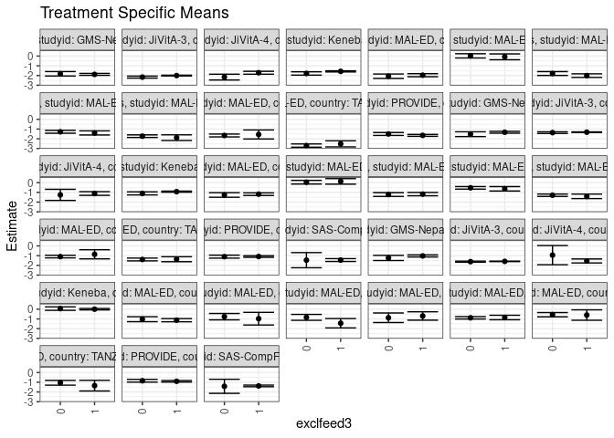

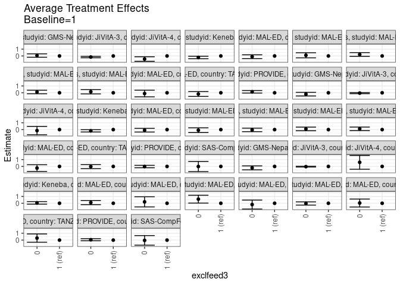

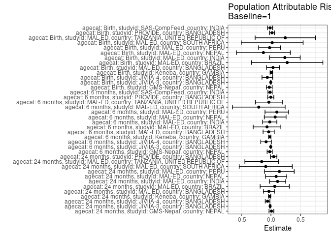

## Results Table

### Parameter: TSM

| agecat | studyid | country | intervention_level | baseline_level | estimate | ci_lower | ci_upper |
| --- | --- | --- | --- | --- | --- | --- | --- |
| Birth | GMS-Nepal | NEPAL | 1 | NA | -1.0279700 | -1.1350477 | -0.9208924 |
| Birth | GMS-Nepal | NEPAL | 0 | NA | -1.2349575 | -1.5008253 | -0.9690896 |
| Birth | JiVitA-3 | BANGLADESH | 1 | NA | -1.5900867 | -1.6137571 | -1.5664163 |
| Birth | JiVitA-3 | BANGLADESH | 0 | NA | -1.6183702 | -1.6737741 | -1.5629662 |
| Birth | JiVitA-4 | BANGLADESH | 1 | NA | -1.5462960 | -1.7510525 | -1.3415396 |
| Birth | JiVitA-4 | BANGLADESH | 0 | NA | -0.9472835 | -1.9333376 | 0.0387707 |
| Birth | Keneba | GAMBIA | 1 | NA | 0.0030689 | -0.0702411 | 0.0763790 |
| Birth | Keneba | GAMBIA | 0 | NA | 0.0608200 | -0.1172098 | 0.2388498 |
| Birth | MAL-ED | BANGLADESH | 1 | NA | -1.1301241 | -1.2913753 | -0.9688729 |
| Birth | MAL-ED | BANGLADESH | 0 | NA | -1.0277361 | -1.2820793 | -0.7733929 |
| Birth | MAL-ED | BRAZIL | 1 | NA | -0.9732980 | -1.6231878 | -0.3234082 |
| Birth | MAL-ED | BRAZIL | 0 | NA | -0.7664875 | -1.0951629 | -0.4378120 |
| Birth | MAL-ED | INDIA | 1 | NA | -1.4421058 | -1.9241947 | -0.9600168 |
| Birth | MAL-ED | INDIA | 0 | NA | -0.8384746 | -1.1412399 | -0.5357094 |
| Birth | MAL-ED | NEPAL | 1 | NA | -0.6962500 | -1.1273498 | -0.2651502 |
| Birth | MAL-ED | NEPAL | 0 | NA | -0.8800000 | -1.3706027 | -0.3893973 |
| Birth | MAL-ED | PERU | 1 | NA | -0.8523496 | -1.0817739 | -0.6229253 |
| Birth | MAL-ED | PERU | 0 | NA | -0.8832424 | -1.0071642 | -0.7593205 |
| Birth | MAL-ED | SOUTH AFRICA | 1 | NA | -0.6006324 | -1.1360629 | -0.0652020 |
| Birth | MAL-ED | SOUTH AFRICA | 0 | NA | -0.5635308 | -0.7826876 | -0.3443739 |
| Birth | MAL-ED | TANZANIA, UNITED REPUBLIC OF | 1 | NA | -1.3501194 | -1.8991010 | -0.8011379 |
| Birth | MAL-ED | TANZANIA, UNITED REPUBLIC OF | 0 | NA | -1.0562667 | -1.3021699 | -0.8103634 |
| Birth | PROVIDE | BANGLADESH | 1 | NA | -0.9034941 | -0.9846215 | -0.8223667 |
| Birth | PROVIDE | BANGLADESH | 0 | NA | -0.8478259 | -0.9892986 | -0.7063532 |
| Birth | SAS-CompFeed | INDIA | 1 | NA | -1.3791852 | -1.4632653 | -1.2951052 |
| Birth | SAS-CompFeed | INDIA | 0 | NA | -1.4188476 | -2.1434587 | -0.6942365 |
| 6 months | GMS-Nepal | NEPAL | 1 | NA | -1.3289785 | -1.4238765 | -1.2340806 |
| 6 months | GMS-Nepal | NEPAL | 0 | NA | -1.5256390 | -1.7718902 | -1.2793877 |
| 6 months | JiVitA-3 | BANGLADESH | 1 | NA | -1.3201245 | -1.3492862 | -1.2909627 |
| 6 months | JiVitA-3 | BANGLADESH | 0 | NA | -1.3651420 | -1.4483796 | -1.2819043 |
| 6 months | JiVitA-4 | BANGLADESH | 1 | NA | -1.1176851 | -1.3061146 | -0.9292557 |
| 6 months | JiVitA-4 | BANGLADESH | 0 | NA | -1.2588429 | -1.8309593 | -0.6867265 |
| 6 months | Keneba | GAMBIA | 1 | NA | -0.9290544 | -0.9831051 | -0.8750038 |
| 6 months | Keneba | GAMBIA | 0 | NA | -1.1080620 | -1.2670329 | -0.9490910 |
| 6 months | MAL-ED | BANGLADESH | 1 | NA | -1.1859101 | -1.3186532 | -1.0531670 |
| 6 months | MAL-ED | BANGLADESH | 0 | NA | -1.2694493 | -1.5031399 | -1.0357586 |
| 6 months | MAL-ED | BRAZIL | 1 | NA | 0.1271661 | -0.1552265 | 0.4095587 |
| 6 months | MAL-ED | BRAZIL | 0 | NA | 0.0444590 | -0.1434504 | 0.2323683 |
| 6 months | MAL-ED | INDIA | 1 | NA | -1.1795996 | -1.3511977 | -1.0080014 |
| 6 months | MAL-ED | INDIA | 0 | NA | -1.2231055 | -1.4142871 | -1.0319240 |
| 6 months | MAL-ED | NEPAL | 1 | NA | -0.6347429 | -0.8626587 | -0.4068271 |
| 6 months | MAL-ED | NEPAL | 0 | NA | -0.5351244 | -0.6657792 | -0.4044696 |
| 6 months | MAL-ED | PERU | 1 | NA | -1.4099181 | -1.6401443 | -1.1796920 |
| 6 months | MAL-ED | PERU | 0 | NA | -1.2950415 | -1.4150026 | -1.1750805 |
| 6 months | MAL-ED | SOUTH AFRICA | 1 | NA | -0.8606589 | -1.3288731 | -0.3924448 |
| 6 months | MAL-ED | SOUTH AFRICA | 0 | NA | -1.0984694 | -1.2335206 | -0.9634182 |
| 6 months | MAL-ED | TANZANIA, UNITED REPUBLIC OF | 1 | NA | -1.3679191 | -1.6229579 | -1.1128802 |
| 6 months | MAL-ED | TANZANIA, UNITED REPUBLIC OF | 0 | NA | -1.3944411 | -1.5374363 | -1.2514458 |
| 6 months | PROVIDE | BANGLADESH | 1 | NA | -1.0888044 | -1.1726338 | -1.0049751 |
| 6 months | PROVIDE | BANGLADESH | 0 | NA | -1.1027490 | -1.2581263 | -0.9473718 |
| 6 months | SAS-CompFeed | INDIA | 1 | NA | -1.4549959 | -1.6008850 | -1.3091069 |
| 6 months | SAS-CompFeed | INDIA | 0 | NA | -1.4654856 | -2.2428805 | -0.6880907 |
| 24 months | GMS-Nepal | NEPAL | 1 | NA | -1.8832865 | -1.9849674 | -1.7816056 |
| 24 months | GMS-Nepal | NEPAL | 0 | NA | -1.8249596 | -2.0529909 | -1.5969283 |
| 24 months | JiVitA-3 | BANGLADESH | 1 | NA | -2.0051160 | -2.0429026 | -1.9673294 |
| 24 months | JiVitA-3 | BANGLADESH | 0 | NA | -2.1629322 | -2.2686254 | -2.0572390 |
| 24 months | JiVitA-4 | BANGLADESH | 1 | NA | -1.7156069 | -1.8632856 | -1.5679282 |
| 24 months | JiVitA-4 | BANGLADESH | 0 | NA | -2.1635926 | -2.4626862 | -1.8644989 |
| 24 months | Keneba | GAMBIA | 1 | NA | -1.5741466 | -1.6310564 | -1.5172368 |
| 24 months | Keneba | GAMBIA | 0 | NA | -1.7897095 | -1.9621852 | -1.6172338 |
| 24 months | MAL-ED | BANGLADESH | 1 | NA | -1.9676008 | -2.1239021 | -1.8112995 |
| 24 months | MAL-ED | BANGLADESH | 0 | NA | -2.0733341 | -2.2986599 | -1.8480083 |
| 24 months | MAL-ED | BRAZIL | 1 | NA | -0.0799773 | -0.3800426 | 0.2200879 |
| 24 months | MAL-ED | BRAZIL | 0 | NA | 0.0177140 | -0.2033449 | 0.2387729 |
| 24 months | MAL-ED | INDIA | 1 | NA | -2.0117210 | -2.1965855 | -1.8268566 |
| 24 months | MAL-ED | INDIA | 0 | NA | -1.7959114 | -1.9928685 | -1.5989543 |
| 24 months | MAL-ED | NEPAL | 1 | NA | -1.3981900 | -1.6092154 | -1.1871647 |
| 24 months | MAL-ED | NEPAL | 0 | NA | -1.2810933 | -1.4273868 | -1.1347999 |
| 24 months | MAL-ED | PERU | 1 | NA | -1.8833910 | -2.1735761 | -1.5932059 |
| 24 months | MAL-ED | PERU | 0 | NA | -1.7300416 | -1.8627356 | -1.5973475 |
| 24 months | MAL-ED | SOUTH AFRICA | 1 | NA | -1.5547560 | -2.0173228 | -1.0921892 |
| 24 months | MAL-ED | SOUTH AFRICA | 0 | NA | -1.6596615 | -1.8053891 | -1.5139339 |
| 24 months | MAL-ED | TANZANIA, UNITED REPUBLIC OF | 1 | NA | -2.5205601 | -2.8330920 | -2.2080281 |
| 24 months | MAL-ED | TANZANIA, UNITED REPUBLIC OF | 0 | NA | -2.6963050 | -2.8606670 | -2.5319430 |
| 24 months | PROVIDE | BANGLADESH | 1 | NA | -1.6488907 | -1.7467645 | -1.5510168 |
| 24 months | PROVIDE | BANGLADESH | 0 | NA | -1.5050134 | -1.6576122 | -1.3524147 |

### Parameter: E(Y)

| agecat | studyid | country | intervention_level | baseline_level | estimate | ci_lower | ci_upper |
| --- | --- | --- | --- | --- | --- | --- | --- |
| Birth | GMS-Nepal | NEPAL | NA | NA | -1.0555240 | -1.1550843 | -0.9559638 |
| Birth | JiVitA-3 | BANGLADESH | NA | NA | -1.5928457 | -1.6158667 | -1.5698248 |
| Birth | JiVitA-4 | BANGLADESH | NA | NA | -1.6073276 | -1.8105798 | -1.4040753 |
| Birth | Keneba | GAMBIA | NA | NA | 0.0098304 | -0.0597854 | 0.0794461 |
| Birth | MAL-ED | BANGLADESH | NA | NA | -1.0949767 | -1.2319917 | -0.9579618 |
| Birth | MAL-ED | BRAZIL | NA | NA | -0.6996491 | -0.9856018 | -0.4136965 |
| Birth | MAL-ED | INDIA | NA | NA | -1.2075610 | -1.5261540 | -0.8889679 |
| Birth | MAL-ED | NEPAL | NA | NA | -0.8234615 | -1.1896049 | -0.4573182 |
| Birth | MAL-ED | PERU | NA | NA | -0.8753812 | -0.9932108 | -0.7575515 |
| Birth | MAL-ED | SOUTH AFRICA | NA | NA | -0.5797000 | -0.7788298 | -0.3805702 |
| Birth | MAL-ED | TANZANIA, UNITED REPUBLIC OF | NA | NA | -1.1086275 | -1.3310338 | -0.8862211 |
| Birth | PROVIDE | BANGLADESH | NA | NA | -0.8851020 | -0.9601332 | -0.8100709 |
| Birth | SAS-CompFeed | INDIA | NA | NA | -1.3937088 | -1.5095039 | -1.2779137 |
| 6 months | GMS-Nepal | NEPAL | NA | NA | -1.3499849 | -1.4387386 | -1.2612312 |
| 6 months | JiVitA-3 | BANGLADESH | NA | NA | -1.3240051 | -1.3526414 | -1.2953689 |
| 6 months | JiVitA-4 | BANGLADESH | NA | NA | -1.1994318 | -1.3808291 | -1.0180345 |
| 6 months | Keneba | GAMBIA | NA | NA | -0.9489317 | -1.0001696 | -0.8976937 |
| 6 months | MAL-ED | BANGLADESH | NA | NA | -1.2242918 | -1.3439424 | -1.1046413 |
| 6 months | MAL-ED | BRAZIL | NA | NA | 0.0609091 | -0.0944768 | 0.2162950 |
| 6 months | MAL-ED | INDIA | NA | NA | -1.2002381 | -1.3274929 | -1.0729833 |
| 6 months | MAL-ED | NEPAL | NA | NA | -0.5634068 | -0.6769687 | -0.4498449 |
| 6 months | MAL-ED | PERU | NA | NA | -1.3108735 | -1.4182407 | -1.2035062 |
| 6 months | MAL-ED | SOUTH AFRICA | NA | NA | -1.0662227 | -1.1965862 | -0.9358591 |
| 6 months | MAL-ED | TANZANIA, UNITED REPUBLIC OF | NA | NA | -1.4030503 | -1.5292443 | -1.2768563 |
| 6 months | PROVIDE | BANGLADESH | NA | NA | -1.0916915 | -1.1661176 | -1.0172654 |
| 6 months | SAS-CompFeed | INDIA | NA | NA | -1.4697236 | -1.6333919 | -1.3060553 |
| 24 months | GMS-Nepal | NEPAL | NA | NA | -1.8752995 | -1.9688053 | -1.7817937 |
| 24 months | JiVitA-3 | BANGLADESH | NA | NA | -2.0187325 | -2.0554682 | -1.9819968 |
| 24 months | JiVitA-4 | BANGLADESH | NA | NA | -1.7726490 | -1.9111913 | -1.6341067 |
| 24 months | Keneba | GAMBIA | NA | NA | -1.5961170 | -1.6505261 | -1.5417080 |
| 24 months | MAL-ED | BANGLADESH | NA | NA | -2.0016585 | -2.1303297 | -1.8729874 |
| 24 months | MAL-ED | BRAZIL | NA | NA | -0.0162939 | -0.1929098 | 0.1603221 |
| 24 months | MAL-ED | INDIA | NA | NA | -1.8994059 | -2.0346781 | -1.7641337 |
| 24 months | MAL-ED | NEPAL | NA | NA | -1.3109318 | -1.4313748 | -1.1904888 |
| 24 months | MAL-ED | PERU | NA | NA | -1.7412963 | -1.8630698 | -1.6195228 |
| 24 months | MAL-ED | SOUTH AFRICA | NA | NA | -1.6424525 | -1.7808926 | -1.5040124 |
| 24 months | MAL-ED | TANZANIA, UNITED REPUBLIC OF | NA | NA | -2.6768207 | -2.8213178 | -2.5323235 |
| 24 months | PROVIDE | BANGLADESH | NA | NA | -1.6024221 | -1.6857420 | -1.5191023 |

### Parameter: ATE

| agecat | studyid | country | intervention_level | baseline_level | estimate | ci_lower | ci_upper |
| --- | --- | --- | --- | --- | --- | --- | --- |
| Birth | GMS-Nepal | NEPAL | 1 | 1 | 0.0000000 | 0.0000000 | 0.0000000 |
| Birth | GMS-Nepal | NEPAL | 0 | 1 | -0.2069874 | -0.4936940 | 0.0797191 |
| Birth | JiVitA-3 | BANGLADESH | 1 | 1 | 0.0000000 | 0.0000000 | 0.0000000 |
| Birth | JiVitA-3 | BANGLADESH | 0 | 1 | -0.0282835 | -0.0840300 | 0.0274630 |
| Birth | JiVitA-4 | BANGLADESH | 1 | 1 | 0.0000000 | 0.0000000 | 0.0000000 |
| Birth | JiVitA-4 | BANGLADESH | 0 | 1 | 0.5990126 | -0.4058124 | 1.6038375 |
| Birth | Keneba | GAMBIA | 1 | 1 | 0.0000000 | 0.0000000 | 0.0000000 |
| Birth | Keneba | GAMBIA | 0 | 1 | 0.0577511 | -0.1278114 | 0.2433136 |
| Birth | MAL-ED | BANGLADESH | 1 | 1 | 0.0000000 | 0.0000000 | 0.0000000 |
| Birth | MAL-ED | BANGLADESH | 0 | 1 | 0.1023880 | -0.1997411 | 0.4045171 |
| Birth | MAL-ED | BRAZIL | 1 | 1 | 0.0000000 | 0.0000000 | 0.0000000 |
| Birth | MAL-ED | BRAZIL | 0 | 1 | 0.2068105 | -0.5317645 | 0.9453856 |
| Birth | MAL-ED | INDIA | 1 | 1 | 0.0000000 | 0.0000000 | 0.0000000 |
| Birth | MAL-ED | INDIA | 0 | 1 | 0.6036311 | 0.0282638 | 1.1789984 |
| Birth | MAL-ED | NEPAL | 1 | 1 | 0.0000000 | 0.0000000 | 0.0000000 |
| Birth | MAL-ED | NEPAL | 0 | 1 | -0.1837500 | -0.8368488 | 0.4693488 |
| Birth | MAL-ED | PERU | 1 | 1 | 0.0000000 | 0.0000000 | 0.0000000 |
| Birth | MAL-ED | PERU | 0 | 1 | -0.0308927 | -0.2677463 | 0.2059608 |
| Birth | MAL-ED | SOUTH AFRICA | 1 | 1 | 0.0000000 | 0.0000000 | 0.0000000 |
| Birth | MAL-ED | SOUTH AFRICA | 0 | 1 | 0.0371017 | -0.5422881 | 0.6164914 |
| Birth | MAL-ED | TANZANIA, UNITED REPUBLIC OF | 1 | 1 | 0.0000000 | 0.0000000 | 0.0000000 |
| Birth | MAL-ED | TANZANIA, UNITED REPUBLIC OF | 0 | 1 | 0.2938528 | -0.3099216 | 0.8976271 |
| Birth | PROVIDE | BANGLADESH | 1 | 1 | 0.0000000 | 0.0000000 | 0.0000000 |
| Birth | PROVIDE | BANGLADESH | 0 | 1 | 0.0556682 | -0.0954537 | 0.2067901 |
| Birth | SAS-CompFeed | INDIA | 1 | 1 | 0.0000000 | 0.0000000 | 0.0000000 |
| Birth | SAS-CompFeed | INDIA | 0 | 1 | -0.0396624 | -0.7382457 | 0.6589209 |
| 6 months | GMS-Nepal | NEPAL | 1 | 1 | 0.0000000 | 0.0000000 | 0.0000000 |
| 6 months | GMS-Nepal | NEPAL | 0 | 1 | -0.1966604 | -0.4610673 | 0.0677464 |
| 6 months | JiVitA-3 | BANGLADESH | 1 | 1 | 0.0000000 | 0.0000000 | 0.0000000 |
| 6 months | JiVitA-3 | BANGLADESH | 0 | 1 | -0.0450175 | -0.1291387 | 0.0391038 |
| 6 months | JiVitA-4 | BANGLADESH | 1 | 1 | 0.0000000 | 0.0000000 | 0.0000000 |
| 6 months | JiVitA-4 | BANGLADESH | 0 | 1 | -0.1411578 | -0.7477337 | 0.4654181 |
| 6 months | Keneba | GAMBIA | 1 | 1 | 0.0000000 | 0.0000000 | 0.0000000 |
| 6 months | Keneba | GAMBIA | 0 | 1 | -0.1790075 | -0.3464561 | -0.0115590 |
| 6 months | MAL-ED | BANGLADESH | 1 | 1 | 0.0000000 | 0.0000000 | 0.0000000 |
| 6 months | MAL-ED | BANGLADESH | 0 | 1 | -0.0835391 | -0.3519848 | 0.1849065 |
| 6 months | MAL-ED | BRAZIL | 1 | 1 | 0.0000000 | 0.0000000 | 0.0000000 |
| 6 months | MAL-ED | BRAZIL | 0 | 1 | -0.0827072 | -0.4229995 | 0.2575852 |
| 6 months | MAL-ED | INDIA | 1 | 1 | 0.0000000 | 0.0000000 | 0.0000000 |
| 6 months | MAL-ED | INDIA | 0 | 1 | -0.0435060 | -0.3008808 | 0.2138689 |
| 6 months | MAL-ED | NEPAL | 1 | 1 | 0.0000000 | 0.0000000 | 0.0000000 |
| 6 months | MAL-ED | NEPAL | 0 | 1 | 0.0996185 | -0.1637956 | 0.3630326 |
| 6 months | MAL-ED | PERU | 1 | 1 | 0.0000000 | 0.0000000 | 0.0000000 |
| 6 months | MAL-ED | PERU | 0 | 1 | 0.1148766 | -0.1405111 | 0.3702643 |
| 6 months | MAL-ED | SOUTH AFRICA | 1 | 1 | 0.0000000 | 0.0000000 | 0.0000000 |
| 6 months | MAL-ED | SOUTH AFRICA | 0 | 1 | -0.2378105 | -0.7251843 | 0.2495633 |
| 6 months | MAL-ED | TANZANIA, UNITED REPUBLIC OF | 1 | 1 | 0.0000000 | 0.0000000 | 0.0000000 |
| 6 months | MAL-ED | TANZANIA, UNITED REPUBLIC OF | 0 | 1 | -0.0265220 | -0.3145405 | 0.2614965 |
| 6 months | PROVIDE | BANGLADESH | 1 | 1 | 0.0000000 | 0.0000000 | 0.0000000 |
| 6 months | PROVIDE | BANGLADESH | 0 | 1 | -0.0139446 | -0.1904723 | 0.1625831 |
| 6 months | SAS-CompFeed | INDIA | 1 | 1 | 0.0000000 | 0.0000000 | 0.0000000 |
| 6 months | SAS-CompFeed | INDIA | 0 | 1 | -0.0104897 | -0.7471588 | 0.7261794 |
| 24 months | GMS-Nepal | NEPAL | 1 | 1 | 0.0000000 | 0.0000000 | 0.0000000 |
| 24 months | GMS-Nepal | NEPAL | 0 | 1 | 0.0583269 | -0.1895180 | 0.3061718 |
| 24 months | JiVitA-3 | BANGLADESH | 1 | 1 | 0.0000000 | 0.0000000 | 0.0000000 |
| 24 months | JiVitA-3 | BANGLADESH | 0 | 1 | -0.1578162 | -0.2664410 | -0.0491914 |
| 24 months | JiVitA-4 | BANGLADESH | 1 | 1 | 0.0000000 | 0.0000000 | 0.0000000 |
| 24 months | JiVitA-4 | BANGLADESH | 0 | 1 | -0.4479857 | -0.7801169 | -0.1158545 |
| 24 months | Keneba | GAMBIA | 1 | 1 | 0.0000000 | 0.0000000 | 0.0000000 |
| 24 months | Keneba | GAMBIA | 0 | 1 | -0.2155629 | -0.3960118 | -0.0351141 |
| 24 months | MAL-ED | BANGLADESH | 1 | 1 | 0.0000000 | 0.0000000 | 0.0000000 |
| 24 months | MAL-ED | BANGLADESH | 0 | 1 | -0.1057333 | -0.3778224 | 0.1663559 |
| 24 months | MAL-ED | BRAZIL | 1 | 1 | 0.0000000 | 0.0000000 | 0.0000000 |
| 24 months | MAL-ED | BRAZIL | 0 | 1 | 0.0976913 | -0.2748619 | 0.4702445 |
| 24 months | MAL-ED | INDIA | 1 | 1 | 0.0000000 | 0.0000000 | 0.0000000 |
| 24 months | MAL-ED | INDIA | 0 | 1 | 0.2158096 | -0.0532282 | 0.4848474 |
| 24 months | MAL-ED | NEPAL | 1 | 1 | 0.0000000 | 0.0000000 | 0.0000000 |
| 24 months | MAL-ED | NEPAL | 0 | 1 | 0.1170967 | -0.1396006 | 0.3737940 |
| 24 months | MAL-ED | PERU | 1 | 1 | 0.0000000 | 0.0000000 | 0.0000000 |
| 24 months | MAL-ED | PERU | 0 | 1 | 0.1533494 | -0.1643743 | 0.4710732 |
| 24 months | MAL-ED | SOUTH AFRICA | 1 | 1 | 0.0000000 | 0.0000000 | 0.0000000 |
| 24 months | MAL-ED | SOUTH AFRICA | 0 | 1 | -0.1049055 | -0.5897878 | 0.3799769 |
| 24 months | MAL-ED | TANZANIA, UNITED REPUBLIC OF | 1 | 1 | 0.0000000 | 0.0000000 | 0.0000000 |
| 24 months | MAL-ED | TANZANIA, UNITED REPUBLIC OF | 0 | 1 | -0.1757449 | -0.5282223 | 0.1767325 |
| 24 months | PROVIDE | BANGLADESH | 1 | 1 | 0.0000000 | 0.0000000 | 0.0000000 |
| 24 months | PROVIDE | BANGLADESH | 0 | 1 | 0.1438773 | -0.0358163 | 0.3235709 |

### Parameter: PAR

| agecat | studyid | country | intervention_level | baseline_level | estimate | ci_lower | ci_upper |
| --- | --- | --- | --- | --- | --- | --- | --- |
| Birth | GMS-Nepal | NEPAL | 1 | NA | -0.0275540 | -0.0764854 | 0.0213774 |
| Birth | JiVitA-3 | BANGLADESH | 1 | NA | -0.0027590 | -0.0080085 | 0.0024905 |
| Birth | JiVitA-4 | BANGLADESH | 1 | NA | -0.0610316 | -0.1512063 | 0.0291431 |
| Birth | Keneba | GAMBIA | 1 | NA | 0.0067615 | -0.0142650 | 0.0277879 |
| Birth | MAL-ED | BANGLADESH | 1 | NA | 0.0351473 | -0.0729465 | 0.1432412 |
| Birth | MAL-ED | BRAZIL | 1 | NA | 0.2736489 | -0.3274165 | 0.8747142 |
| Birth | MAL-ED | INDIA | 1 | NA | 0.2345448 | -0.0235961 | 0.4926857 |
| Birth | MAL-ED | NEPAL | 1 | NA | -0.1272115 | -0.5805774 | 0.3261543 |
| Birth | MAL-ED | PERU | 1 | NA | -0.0230315 | -0.2080260 | 0.1619630 |
| Birth | MAL-ED | SOUTH AFRICA | 1 | NA | 0.0209324 | -0.5003753 | 0.5422401 |
| Birth | MAL-ED | TANZANIA, UNITED REPUBLIC OF | 1 | NA | 0.2414920 | -0.2666036 | 0.7495876 |
| Birth | PROVIDE | BANGLADESH | 1 | NA | 0.0183921 | -0.0242469 | 0.0610310 |
| Birth | SAS-CompFeed | INDIA | 1 | NA | -0.0145236 | -0.0577567 | 0.0287095 |
| 6 months | GMS-Nepal | NEPAL | 1 | NA | -0.0210064 | -0.0645221 | 0.0225094 |
| 6 months | JiVitA-3 | BANGLADESH | 1 | NA | -0.0038807 | -0.0113395 | 0.0035782 |
| 6 months | JiVitA-4 | BANGLADESH | 1 | NA | -0.0817467 | -0.1718089 | 0.0083155 |
| 6 months | Keneba | GAMBIA | 1 | NA | -0.0198772 | -0.0390545 | -0.0006999 |
| 6 months | MAL-ED | BANGLADESH | 1 | NA | -0.0383817 | -0.1326635 | 0.0559000 |
| 6 months | MAL-ED | BRAZIL | 1 | NA | -0.0662570 | -0.2991664 | 0.1666524 |
| 6 months | MAL-ED | INDIA | 1 | NA | -0.0206385 | -0.1405634 | 0.0992864 |
| 6 months | MAL-ED | NEPAL | 1 | NA | 0.0713362 | -0.1120736 | 0.2547459 |
| 6 months | MAL-ED | PERU | 1 | NA | 0.0990447 | -0.1003698 | 0.2984591 |
| 6 months | MAL-ED | SOUTH AFRICA | 1 | NA | -0.2055637 | -0.6501370 | 0.2390096 |
| 6 months | MAL-ED | TANZANIA, UNITED REPUBLIC OF | 1 | NA | -0.0351313 | -0.2619624 | 0.1916999 |
| 6 months | PROVIDE | BANGLADESH | 1 | NA | -0.0028871 | -0.0540042 | 0.0482301 |
| 6 months | SAS-CompFeed | INDIA | 1 | NA | -0.0147277 | -0.0507565 | 0.0213012 |
| 24 months | GMS-Nepal | NEPAL | 1 | NA | 0.0079870 | -0.0324204 | 0.0483944 |
| 24 months | JiVitA-3 | BANGLADESH | 1 | NA | -0.0136165 | -0.0230791 | -0.0041539 |
| 24 months | JiVitA-4 | BANGLADESH | 1 | NA | -0.0570421 | -0.0962779 | -0.0178064 |
| 24 months | Keneba | GAMBIA | 1 | NA | -0.0219704 | -0.0403047 | -0.0036361 |
| 24 months | MAL-ED | BANGLADESH | 1 | NA | -0.0340577 | -0.1265842 | 0.0584687 |
| 24 months | MAL-ED | BRAZIL | 1 | NA | 0.0636835 | -0.1821136 | 0.3094806 |
| 24 months | MAL-ED | INDIA | 1 | NA | 0.1123151 | -0.0237427 | 0.2483729 |
| 24 months | MAL-ED | NEPAL | 1 | NA | 0.0872582 | -0.0912312 | 0.2657476 |
| 24 months | MAL-ED | PERU | 1 | NA | 0.1420947 | -0.1074644 | 0.3916538 |
| 24 months | MAL-ED | SOUTH AFRICA | 1 | NA | -0.0876965 | -0.5346705 | 0.3592775 |
| 24 months | MAL-ED | TANZANIA, UNITED REPUBLIC OF | 1 | NA | -0.1562606 | -0.4391655 | 0.1266443 |
| 24 months | PROVIDE | BANGLADESH | 1 | NA | 0.0464686 | -0.0070072 | 0.0999443 |